# Run Random Portfolio Data Processing and Analysis

Author

Mick Cooney mcooney@describedata.com

Published

June 5, 2024

# 1 Load Data

We first want to load the various pieces of data needed to run this workbook.

This data is saved in the repo, but is available online and was retrieved using the code in the `retrieve_data.R` script. It is not necessary to run this script as the data is already saved.

```r
sp500_wikipedia_tbl <- read_rds("retrieved_data/sp500_wikipedia_tbl.rds")

sp500_wikipedia_tbl |> glimpse()
```

```
Rows: 503
Columns: 8
$ symbol                <chr> "A", "AAL", "AAPL", "ABBV", "ABNB", "ABT", "ACGL…
$ security              <chr> "Agilent Technologies", "American Airlines Group…
$ gics_sector           <chr> "Health Care", "Industrials", "Information Techn…
$ gics_sub_industry     <chr> "Life Sciences Tools & Services", "Passenger Air…
$ headquarters_location <chr> "Santa Clara, California", "Fort Worth, Texas", …
$ date_added            <chr> "2000-06-05", "2015-03-23", "1982-11-30", "2012-…
$ cik                   <int> 1090872, 6201, 320193, 1551152, 1559720, 1800, 9…
$ founded               <chr> "1999", "1934", "1977", "2013 (1888)", "2008", "…
```

We now want to retrieve the S&P 500 data obtained from tidyquant.

```r
sp500_tidyquant_tbl <- read_rds("retrieved_data/sp500_tidyquant_tbl.rds")

sp500_tidyquant_tbl |> glimpse()
```

```
Rows: 504
Columns: 8
$ symbol         <chr> "MSFT", "NVDA", "AAPL", "AMZN", "META", "GOOGL", "GOOG"…
$ company        <chr> "MICROSOFT CORP", "NVIDIA CORP", "APPLE INC", "AMAZON.C…
$ identifier     <chr> "594918104", "67066G104", "037833100", "023135106", "30…
$ sedol          <chr> "2588173", "2379504", "2046251", "2000019", "B7TL820", …
$ weight         <dbl> 0.069515117, 0.064667537, 0.063432456, 0.036860789, 0.0…
$ sector         <chr> "-", "-", "-", "-", "-", "-", "-", "-", "-", "-", "-", …
$ shares_held    <dbl> 88721377, 29492440, 173317472, 109144753, 26269128, 703…
$ local_currency <chr> "USD", "USD", "USD", "USD", "USD", "USD", "USD", "USD",…
```

Finally, we load the price data retrieved using tidyquant.

```r
sp500_pricedata_tbl <- read_rds("retrieved_data/sp500_pricedata_tbl.rds")

sp500_pricedata_tbl |> glimpse()
```

```
Rows: 503
Columns: 9
$ symbol                <chr> "A", "AAL", "AAPL", "ABBV", "ABNB", "ABT", "ACGL…
$ security              <chr> "Agilent Technologies", "American Airlines Group…
$ gics_sector           <chr> "Health Care", "Industrials", "Information Techn…
$ gics_sub_industry     <chr> "Life Sciences Tools & Services", "Passenger Air…
$ headquarters_location <chr> "Santa Clara, California", "Fort Worth, Texas", …
$ date_added            <chr> "2000-06-05", "2015-03-23", "1982-11-30", "2012-…
$ cik                   <int> 1090872, 6201, 320193, 1551152, 1559720, 1800, 9…
$ founded               <chr> "1999", "1934", "1977", "2013 (1888)", "2008", "…
$ price_data            <list> [<tbl_df[857 x 8]>], [<tbl_df[857 x 8]>], [<tbl…
```

We want to pull out the starting price of each company, as this is used as part of the company weighting.

```r
company_first_price_tbl <- sp500_pricedata_tbl |>
  mutate(
    first_price = map_dbl(
      price_data,
      \(x) x |> arrange(date) |> pull(adjusted) |> extract2(1) |> round(2)
      )
    ) |>
  select(symbol, first_price)

company_first_price_tbl |> glimpse()
```

```
Rows: 503
Columns: 2
$ symbol      <chr> "A", "AAL", "AAPL", "ABBV", "ABNB", "ABT", "ACGL", "ACN", …
$ first_price <dbl> 116.20, 15.13, 126.83, 91.32, 139.15, 102.60, 34.90, 244.1…
```

```r
sp500_companies_tbl <- sp500_wikipedia_tbl |>
  left_join(sp500_tidyquant_tbl, by = "symbol") |>
  mutate(
    company_size = ntile(weight, n = 5)
    ) |>
  filter(
    !(symbol %in% c("GOOG", "FOX", "NWS"))
    ) |>
  left_join(company_first_price_tbl, by = "symbol") |>
  left_join(sp500_pricedata_tbl |> select(symbol, price_data), by = "symbol") |>
  filter(map_int(price_data, nrow) >= 857)

sp500_companies_tbl |> glimpse()
```

```
Rows: 494
Columns: 18
$ symbol                <chr> "A", "AAL", "AAPL", "ABBV", "ABNB", "ABT", "ACGL…
$ security              <chr> "Agilent Technologies", "American Airlines Group…
$ gics_sector           <chr> "Health Care", "Industrials", "Information Techn…
$ gics_sub_industry     <chr> "Life Sciences Tools & Services", "Passenger Air…
$ headquarters_location <chr> "Santa Clara, California", "Fort Worth, Texas", …
$ date_added            <chr> "2000-06-05", "2015-03-23", "1982-11-30", "2012-…
$ cik                   <int> 1090872, 6201, 320193, 1551152, 1559720, 1800, 9…
$ founded               <chr> "1999", "1934", "1977", "2013 (1888)", "2008", "…
$ company               <chr> "AGILENT TECHNOLOGIES INC", "AMERICAN AIRLINES G…
$ identifier            <chr> "00846U101", "02376R102", "037833100", "00287Y10…
$ sedol                 <chr> "2520153", "BCV7KT2", "2046251", "B92SR70", "BMG…
$ weight                <dbl> 0.0008607477, 0.0001689584, 0.0634324560, 0.0064…
$ sector                <chr> "-", "-", "-", "-", "-", "-", "-", "-", "-", "-"…
$ shares_held           <dbl> 3493133, 7801617, 173317472, 21075317, 5190168, …
$ local_currency        <chr> "USD", "USD", "USD", "USD", "USD", "USD", "USD",…
$ company_size          <int> 3, 1, 5, 5, 4, 5, 3, 5, 5, 5, 3, 5, 4, 2, 4, 1, …
$ first_price           <dbl> 116.20, 15.13, 126.83, 91.32, 139.15, 102.60, 34…
$ price_data            <list> [<tbl_df[857 x 8]>], [<tbl_df[857 x 8]>], [<tbl…
```

## 1.1 Calculate Price Returns

We now want to calculate both the daily and cumulative returns for each of the symbols.

```r
company_returns_tbl <- sp500_companies_tbl |>
  select(price_data) |>
  unnest(price_data) |>
  mutate(
    symbol, date,
    daily_return = adjusted / lag(adjusted),

    .by = symbol
    ) |>
  replace_na(list(daily_return = 1)) |>
  select(symbol, date, daily_return) |>
  arrange(symbol, date) |>
  mutate(
    cuml_return = cumprod(daily_return),

    .by = symbol
    )

company_returns_tbl |> glimpse()
```

```
Rows: 423,358
Columns: 4
$ symbol       <chr> "A", "A", "A", "A", "A", "A", "A", "A", "A", "A", "A", "A…
$ date         <date> 2021-01-04, 2021-01-05, 2021-01-06, 2021-01-07, 2021-01-…
$ daily_return <dbl> 1.0000000, 1.0081761, 1.0274223, 1.0266092, 1.0071338, 1.…
$ cuml_return  <dbl> 1.000000, 1.008176, 1.035823, 1.063385, 1.070971, 1.08015…
```

# 2 Calculate Random Portfolio Returns

We now need to set up some basic risk limits to our portfolios.

Our invested amount is $100 million, and we set the following risk limits:

1. The portfolio should contain a minimum of 100 separate positions.
2. To keep transaction size to a minimum, the portfolio is limited to a maximum of 300 separate positions.
3. The minimum investment any one symbol is $100,000.00
4. No more than 30% can be allocated to any sector.
5. No more than 20% can be allocated to any sub-industry.
6. No more than 40% of the portfolio can be allocated to any one size category

```r
determine_portfolio_within_risk_limits <- function(portfolio_tbl) {

  check_min_symbol_count <- portfolio_tbl |>
    nrow() |>
    is_weakly_greater_than(100)


  check_max_symbol_count <- portfolio_tbl |>
    nrow() |>
    is_weakly_less_than(300)


  check_minimum_amount <- portfolio_tbl |>
    pull(component_amount) |>
    min() |>
    is_weakly_greater_than(100e3)


  check_sector_allocation <- portfolio_tbl |>
    summarise(
      sector_amount = sum(component_amount),

      .by = gics_sector
      ) |>
    mutate(
      sector_weight = sector_amount / sum(sector_amount)
      ) |>
    filter(sector_weight > 0.3) |>
    nrow() |>
    equals(0)


  check_subindustry_allocation <- portfolio_tbl |>
    summarise(
      sub_industry_amount = sum(component_amount),

      .by = gics_sub_industry
      ) |>
    mutate(
      sub_industry_weight = sub_industry_amount / sum(sub_industry_amount)
      ) |>
    filter(sub_industry_weight > 0.2) |>
    nrow() |>
    equals(0)


  check_company_size_allocation <- portfolio_tbl |>
    summarise(
      size_amount = sum(component_amount),

      .by = company_size
      ) |>
    mutate(
      size_weight = size_amount / sum(size_amount)
      ) |>
    filter(
      size_weight > 0.40
      ) |>
    nrow() |>
    equals(0)


  return(
    check_min_symbol_count & check_max_symbol_count & check_minimum_amount &
    check_sector_allocation & check_subindustry_allocation &
    check_company_size_allocation
    )
}
```

```r
generate_random_portfolio <- function(symbol_data_tbl, portfolio_size = 100e6,
                                      min_count = 100, max_count = 300, attempt_count = 500) {

  portfolio_is_valid <- FALSE
  iter_count <- 1

  symbol_count <- sample(min_count:max_count, size = 1, replace = FALSE)

  subportfolio_tbl <- symbol_data_tbl |>
    select(-price_data) |>
    slice_sample(n = symbol_count, replace = FALSE)

  while(!portfolio_is_valid & iter_count <= attempt_count) {

    positions_tbl <- subportfolio_tbl |>
      mutate(
        portfolio_weight = rdirichlet(n = 1, alpha = rep(3, n()))[1,] |> pmax(100e3 / 100e6),
        portfolio_weight = portfolio_weight / sum(portfolio_weight),
        component_amount = portfolio_size * portfolio_weight,
        share_count      = round(portfolio_size * portfolio_weight / first_price, 0)
        )

    portfolio_is_valid <- positions_tbl |>
      determine_portfolio_within_risk_limits()

    if(!portfolio_is_valid) iter_count <- iter_count + 1
  }

  return(list(
    iter_count    = iter_count,
    portfolio_data = positions_tbl |> arrange(symbol)
    ))

  return(positions_tbl)
}
```

## 2.1 Generate Random Portfolios

We now want to generate 1,000 random portfolios that fit within the risk profiles.

```r
n_portfolio <- 1000
n_attempt   <-  200

run_portfolio_sim <- function(output_file) {
  sim_lst <- generate_random_portfolio(sp500_companies_tbl, attempt_count = n_attempt)

  sim_lst |> write_rds(output_file)

  return(sim_lst$iter_count)
}

sim_data_tbl <- tibble(
    sim_id = sprintf("PORT%04d", 1:(2 * n_portfolio))
    ) |>
  mutate(
    cached_file = glue("precomputed_data/portfolio_{sim_id}.rds") |> as.character()
    )

existing_tbl <- dir_ls("precomputed_data", regexp = "\\.rds") |>
  enframe(name = NULL, value = "cached_file")


run_code_tbl <- sim_data_tbl |>
  anti_join(existing_tbl, by = "cached_file") |>
  mutate(
    iter_count = future_map_int(
      cached_file, run_portfolio_sim,

      .options = furrr_options(
        globals    = TRUE,
        seed       = 421,
        scheduling = Inf
        ),

      .progress = TRUE
      )
    )

sim_portfolio_tbl <- sim_data_tbl |>
  mutate(
    data           = map(cached_file, read_rds),
    iter_count     = map_int(data, 'iter_count'),
    portfolio_data = map(data, "portfolio_data")
    ) |>
  filter(iter_count < n_attempt + 1) |>
  head(n_portfolio) |>
  select(sim_id, cached_file, iter_count, portfolio_data)

sim_portfolio_tbl |> glimpse()
```

```
Rows: 1,000
Columns: 4
$ sim_id         <chr> "PORT0001", "PORT0003", "PORT0005", "PORT0007", "PORT00…
$ cached_file    <chr> "precomputed_data/portfolio_PORT0001.rds", "precomputed…
$ iter_count     <int> 2, 50, 4, 170, 3, 2, 12, 11, 1, 1, 10, 3, 2, 61, 3, 7, …
$ portfolio_data <list> [<tbl_df[103 x 20]>], [<tbl_df[195 x 20]>], [<tbl_df[1…
```

## 2.2 Combine Portfolio Data with Returns Data

Now that we have portfolio data for our simulations we combine this with the daily return data to calculate the overall return for each portfolio.

```r
sim_portfolio_nav_tbl <- sim_portfolio_tbl |>
  select(sim_id, portfolio_data) |>
  unnest(portfolio_data) |>
  select(sim_id, symbol, gics_sector, gics_sub_industry, component_amount) |>
  inner_join(
    company_returns_tbl, by = "symbol",
    relationship = "many-to-many"
    ) |>
  summarise(
    portfolio_value = sum(component_amount * cuml_return),
    .by = c(sim_id, date)
    )

sim_portfolio_nav_tbl |> glimpse()
```

```
Rows: 857,000
Columns: 3
$ sim_id          <chr> "PORT0001", "PORT0001", "PORT0001", "PORT0001", "PORT0…
$ date            <date> 2021-01-04, 2021-01-05, 2021-01-06, 2021-01-07, 2021-…
$ portfolio_value <dbl> 100000000, 100794012, 102784926, 103955513, 104319477,…
```

We now take the final NAV for each portfolio and calculate an annualised return for that portfolio (based on 252 trading days in the year). This gives us a distribution of returns based on the chosen risk profile

```r
sim_portfolio_return_tbl <- sim_portfolio_nav_tbl |>
  slice_max(order_by = date, n = 1, with_ties = FALSE, by = sim_id) |>
  mutate(
    annual_return = (portfolio_value / 100e6) ^ (252 / 857) - 1
    ) |>
  select(sim_id, final_nav = portfolio_value, annual_return)

sim_portfolio_return_tbl |> glimpse()
```

```
Rows: 1,000
Columns: 3
$ sim_id        <chr> "PORT0001", "PORT0003", "PORT0005", "PORT0007", "PORT000…
$ final_nav     <dbl> 157012216, 142963004, 151522829, 151676627, 155960874, 1…
$ annual_return <dbl> 0.14186309, 0.11081917, 0.12997646, 0.13031360, 0.139609…
```

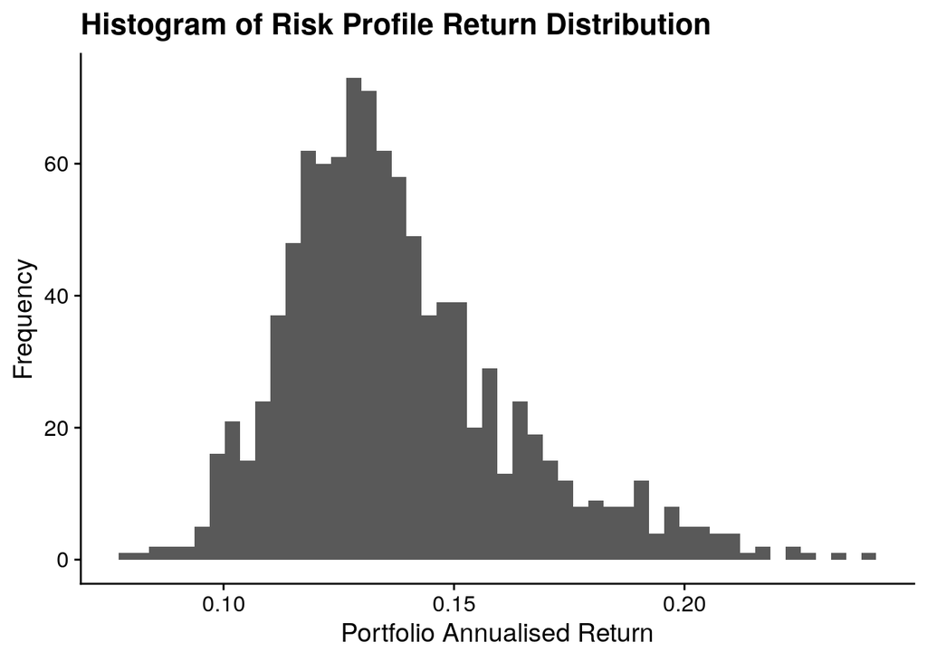

```r
ggplot(sim_portfolio_return_tbl) +
  geom_histogram(aes(x = annual_return), bins = 50) +
  labs(
    x = "Portfolio Annualised Return",
    y = "Frequency",
    title = "Histogram of Risk Profile Return Distribution"
    )
```

# R Environment

```r
options(width = 120L)
```

```r
options(width = 80L)
```